# lab2

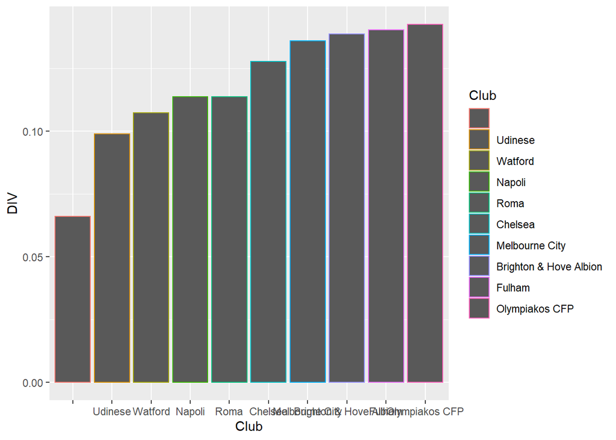

```r
# Plot DIV (diversity?) of different nationalities in each club
g <- ggplot(data = DIV_in_club %>% head(10),aes(x = Club,y = DIV, color = Club))
g <- g + geom_bar(stat="identity")
g
```

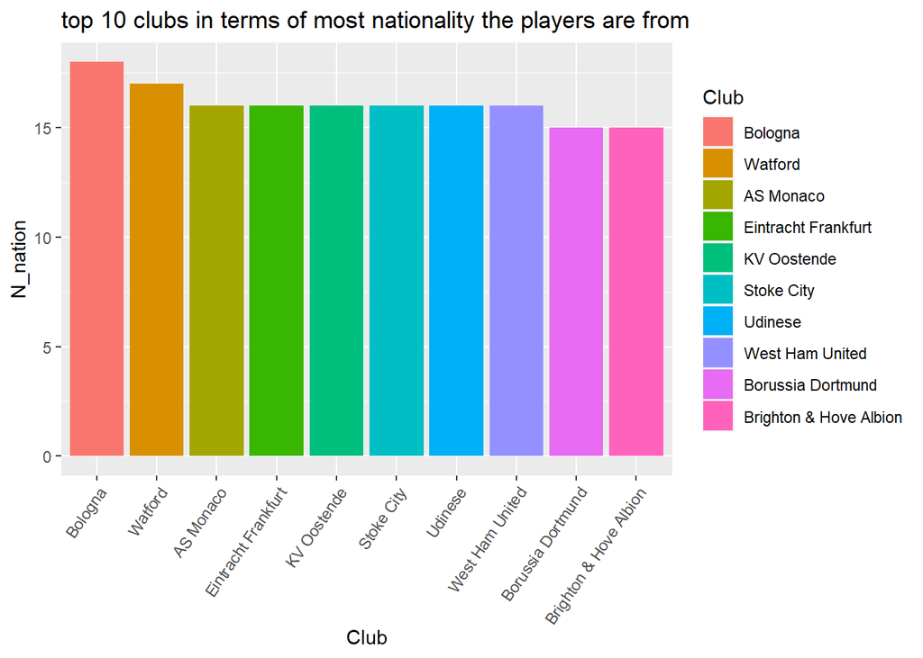

```r
#Q_4
# A

# in the first plot, we see the 10 clubs with the most diffrent Countries the players came from (top 10).

# in the secend plot, we see the Index of diverrsity (similerly to the Herfindahlג€“Hirschman Index) at each  # club ( the 10 least concentrated club).
# *here we look at the amount of players from each country


# B

# problem 1 -
#  ׳. the colors with names the colors have to be more reasonable                                              #     fill color and not outline color
#  ׳‘. the  names under the axsis - x its need to be readable and it's one on top of the other
# problem 2 - we need subtitle on the top of the graph that easily we can analyze the data
# problem 3 - he refer to the players without club as one of the top 10 clubs and we want to check the club    # statistics so we need to throw out the players that without a club and refer only                            # to the players that have  a club


# c

# A measure of category's diversity
DIV <- function(category_vec){
  t <- table(category_vec)
  p <- t/sum(t)
  return(sum(p^2))
}

cleaned_data <- fifa_players %>% select(Nationality,Club) %>% na.omit()
cleaned_data <- cleaned_data[!(cleaned_data$Club==""), ] # throw out the players that without a club

DIV_in_club <- cleaned_data %>% group_by(Club) %>% summarise(DIV = DIV(Nationality))%>% arrange(DIV)%>% mutate(Club = factor(Club,level=unique(Club)))  # arrange(desc(DIV)) %>%


number_of_nationality_in_club <- cleaned_data %>% group_by(Club,Nationality) %>% summarise(count = n()) %>% group_by(Club) %>% summarise(N_nation=n()) %>% arrange(desc(N_nation)) %>% mutate(Club = factor(Club,level=unique(Club)))

# Plot number of different nationalities in each club
g <- ggplot(data = number_of_nationality_in_club %>% head(10),aes(x = Club,y = N_nation,fill= Club))
g + geom_bar(stat="identity") +
theme(axis.text.x = element_text(angle = 55, hjust = 1))+
ggtitle("top 10 clubs in terms of most nationality the players are from")
```

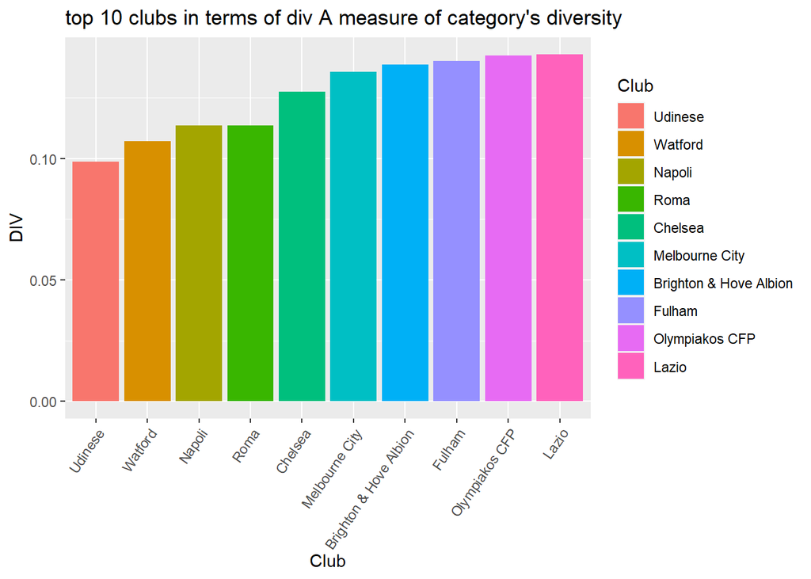

```r
# Plot DIV (diversity?) of different nationalities in each club
g <- ggplot(data = DIV_in_club %>% head(10),aes(x = Club,y = DIV, fill = Club))
g + geom_bar(stat="identity") +
theme(axis.text.x = element_text(angle = 55, hjust = 1))+
ggtitle("top 10 clubs in terms of div A measure of category's diversity")
```

## Q5. Back to the real world (10 pt)

Your boss is not convinced that your analysis of the fifa18 dataset is relevant for performance in the real world. To convince her, you need to show her that the fifa18 data can predict actual performance in football. Load the fifa ranking dataset [‘fifa_ranking.csv’](https://raw.githubusercontent.com/DataScienceHU/DataAnalysisR_2020/master/data/fifa_ranking.csv) which contains ranking of countries based on their actual performance in international football competitions. Use the fifa18 dataset to compare the real vs. game football levels across all countries. What is your conclusion regarding the relevancy of the fifa18 game dataset to the real world? Use your best judgment to choose the appropriate data, models, analysis and plots to support your conclusions.

PLEASE ADD YOUR SOLUTION BELOW, WITH A CLEAR SEPARATION BETWEEN THE PARTS!

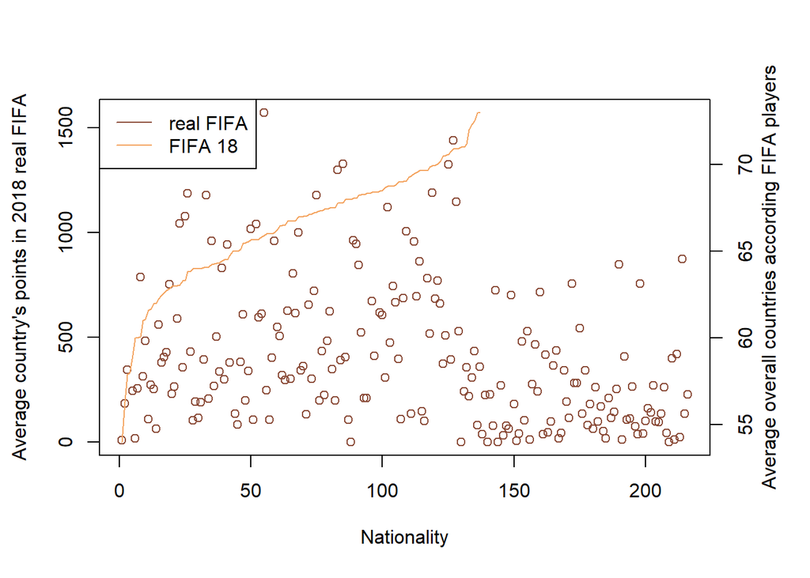

```r
fifa_real <- data.frame(read.csv(url("https://raw.githubusercontent.com/DataScienceHU/DataAnalysisR_2020/master/data/fifa_ranking.csv")))

fifa_real$rank_date<- as.Date(fifa_real$rank_date)
fifa_real$rank_date <- format(fifa_real$rank_date, "%Y")

fifa_real18 <- fifa_real
fifa_real18 <- fifa_real18[ which(fifa_real18$rank_date == 2018),]

fifa_year18.agg <- setNames(aggregate(cbind(as.numeric(as.character(total_points))) ~ country_full, data = fifa_real18, FUN = mean), c("Nationality", "avg_points"))

fifa_game.agg <- setNames(aggregate(cbind(as.numeric(as.character(Overall))) ~ Nationality, data = fifa_players, FUN = mean), c("Nationality", "avg_overall"))

fifa_year18.agg <- fifa_year18.agg[order(fifa_year18.agg$Nationality),]

fifa_game.agg <- fifa_game.agg[order(fifa_game.agg$Nationality),]

fifa_vs_reality.agg <- merge(fifa_year18.agg, fifa_game.agg, by.x = 1, all = T)

fifa_vs_reality.agg <- fifa_vs_reality.agg[order(fifa_vs_reality.agg$avg_overall),]

par(mar = c(5, 4, 4, 4) + 0.3)
plot(fifa_vs_reality.agg[1:length(fifa_vs_reality.agg$Nationality), 2], type ="p", ylab = "Average country's points in 2018 real FIFA", main = "", xlab = "Nationality", col = "salmon4")
par(new = TRUE)
plot(fifa_vs_reality.agg[,3], type = "l", xaxt = "n", yaxt = "number", ylab = "", xlab = "", col = "sandybrown")
axis(4)
mtext("Average overall countries according FIFA players", side = 4, line = 2)
legend("topleft", c("real FIFA", "FIFA 18"), col = c("salmon4", "sandybrown"), lty = c(1, 1))
```

```r
num <- c(1)
fifa_p <- data.frame(fifa_players$Nationality, num)
fifa_number <- data.frame()
fifa_number <- setNames(aggregate(cbind(as.numeric(as.character(num))) ~ fifa_players.Nationality, data = fifa_p, FUN = sum), c("Nationality", "num"))

fifa_vs_reality.agg <- merge(fifa_vs_reality.agg, fifa_number, all = TRUE)

regression = lm(avg_points ~ avg_overall, data=fifa_vs_reality.agg)
summary(regression)
```

```
##
## Call:
## lm(formula = avg_points ~ avg_overall, data = fifa_vs_reality.agg)
##
## Residuals:
##     Min      1Q  Median      3Q     Max
## -603.85 -253.39  -89.87  153.04 1070.69
##
## Coefficients:
##             Estimate Std. Error t value Pr(>|t|)
## (Intercept) -786.799    593.899  -1.325    0.188
## avg_overall   19.587      8.928   2.194    0.030 *
## ---
## Signif. codes:  0 '***' 0.001 '**' 0.01 '*' 0.05 '.' 0.1 ' ' 1
##
## Residual standard error: 347.9 on 130 degrees of freedom
##   (84 observations deleted due to missingness)
## Multiple R-squared:  0.0357, Adjusted R-squared:  0.02828
## F-statistic: 4.813 on 1 and 130 DF,  p-value: 0.03002
```

#TL:DR - we think that there *is* a correlation between the game and the real world we think that between the 2 data sets theres a correlation, even though according to the first graph we can’e see a perfect match. but, according our model we can see that there is a correlation between fifa18 and the reality. we also can add an explenation that the majority of the great players that acctualy changes the gaming scores *do* exist in the reality and in Fifa, and that why the line we added at the first graph shows that the majority is what really set the tone and what really means if we have correlation or not.